# lecture13

# split-apply-combine

A common data analysis task has three general steps:

-**Split** whatever data object we have into meaningful chunks -**Apply** the function of interest to this division -**Combine** the results into a new object.

*apply() and related functions ========================================================

- apply()
- tapply() #takes a factor and applies a function to it
- sapply() #takes a list/vector and applies a function to it
- split()

All useful, but output can be hard to control.

# Show example

```r
setwd("/Users/ankitashankhdhar/Documents/Grad 2nd yr/Comp Stats/Lecture Notes")
data <- read.csv("debt.csv")
# find the max growth of each country
max.growths <- tapply(data$growth, data$Country, max)
# seems like a vector
max.growths[1:3]
```

```
## Australia   Austria   Belgium
##  6.920201 27.329193 15.216302
```

```r
# but R says no its not
is.vector(max.growths)
```

```
## [1] FALSE
```

Huh?

# Example can be cleaned up…

```r
# gets the names of the output which in our case are the countries
names(max.growths)[1:3]
```

```
## [1] "Australia" "Austria"   "Belgium"
```

```r
# puts this all in a data frame
data.frame(country = names(max.growths), max.growth = as.vector(max.growths))[1:5,
    ]
```

```
##     country max.growth
## 1 Australia   6.920201
## 2   Austria  27.329193
## 3   Belgium  15.216302
## 4    Canada   9.338816
## 5   Denmark   9.355186
```

# plyr library is an easier way

- Need to install the package (tools menu item) and load the library

```r
library(plyr)
```

- main function syntax is: ?*ply() (? is the input data type and* is the output data type)
- ? = input data type: d, l, a (data frame, list, or array)
- - = outut data type: d, l, a, _ (_ = nothing)

# Author: Hadley Wickham

Hadley Wickham (2011). The Split-Apply-Combine Strategy for Data Analysis. Journal of Statistical Software, 40(1), 1-29. http://www.jstatsoft.org/v40/i01/.

today: d*ply =======

syntax: output <- d*ply(.data, .(splitvariable), .fun, …)

Here the **.data** is the dataframe you want to apply it to, **.(splitvariable)** the variable you want to split by and **.fun** is the function you want to apply to it. Here the **.()** are a part of syntax.

- .data – data frame
- .(…) – arguments to split by
- .fun – the function to be applied
- … – additional arguments to function

# ddply

```r
# summarize is required to get it in the format we want (part of the syntax)
ddply(data, .(Country), summarize, max.growth = max(growth))[1:5, ]
```

```
##     Country max.growth
## 1 Australia   6.920201
## 2   Austria  27.329193
## 3   Belgium  15.216302
## 4    Canada   9.338816
## 5   Denmark   9.355186
```

# plyr library is an easier way

```r
dlply(data, .(Country), summarize, max.growth = max(growth))
```

```
## $Australia
##   max.growth
## 1   6.920201
##
## $Austria
##   max.growth
## 1   27.32919
##
## $Belgium
##   max.growth
## 1    15.2163
##
## $Canada
##   max.growth
## 1   9.338816
##
## $Denmark
##   max.growth
## 1   9.355186
##
## $Finland
##   max.growth
## 1   9.630896
##
## $France
##   max.growth
## 1   7.494005
##
## $Germany
##   max.growth
## 1   11.00375
##
## $Greece
##   max.growth
## 1   12.44359
##
## $Ireland
##   max.growth
## 1       11.5
##
```

[output cut: 49 more lines]

```
## 6      Finland
## 7       France
## 8      Germany
## 9       Greece
## 10     Ireland
## 11       Italy
## 12       Japan
## 13 Netherlands
## 14 New Zealand
## 15      Norway
## 16    Portugal
## 17       Spain
## 18      Sweden
## 19          UK
## 20          US
```

# What does this do?

```r
# not using summarize here we are applying it to the whole data
ddply(data, .(Country), c("nrow", "ncol"))[1:5, ]
```

```
##     Country nrow ncol
## 1 Australia   64    4
## 2   Austria   59    4
## 3   Belgium   63    4
## 4    Canada   64    4
## 5   Denmark   56    4
```

# What does this do?

```r
# looking at the growth to debt ratio
cor.by.country <- function(one.c.data) cor(one.c.data$growth, one.c.data$ratio)
# input data frame = data split variable = Country the function you want to
# apply = cor.by.country
ddply(data, .(Country), "cor.by.country")[1:5, ]
```

```
##     Country cor.by.country
## 1 Australia     0.02516156
## 2   Austria    -0.25319501
## 3   Belgium    -0.19178175
## 4    Canada     0.07497551
## 5   Denmark    -0.16845880
```

# example with no output

```r
plot.by.country <- function(one.c.data, xlims, ylims) {
    plot(one.c.data$ratio, one.c.data$growth, ylab = "Growth", xlab = "Ratio",
        main = paste(one.c.data$Country[1]), type = "n", xlim = xlims, ylim = ylims,
        sub = paste("Correlation=", round(cor(one.c.data$growth, one.c.data$ratio),
            2)))
    text(one.c.data$ratio, one.c.data$growth, one.c.data$Year, cex = 0.5)
}
```

# Try it on one country’s data

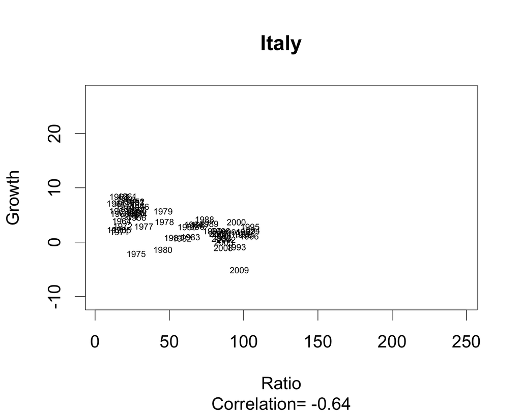

```r
par(cex = 2)
plot.by.country(data[data$Country == "Italy", ], xlims = range(data$ratio),
    ylims = range(data$growth))
```

# Make a book of pdfs

```r
pdf("~/plots.pdf", onefile = T)
d_ply(data, .(Country), plot.by.country, xlims = range(data$ratio), ylims = range(data$growth))

# have a matrix of 5 rows and 4 columns with all of them together
par(mfrow = c(5, 4), cex = 0.5)
d_ply(data, .(Country), plot.by.country, xlims = range(data$ratio), ylims = range(data$growth))
# make the plots so we can look at the pdf
dev.off()
```